# Edge Detection and the Circular Hough Transform

```
Jared Nielsen
```

Here we create two computer vision techniques from scratch: **edge detection** and the **circular Hough transform**.

```python
import matplotlib.pyplot as plt
import matplotlib.image as mpimg
import numpy as np
import cv2
from scipy import ndimage, signal, stats
```

# Load and Display Images

**Edge Detection**: we will use a simple "white box" image and a complicated "Rubik's Cube" image.  
**Circular Hough Transform**: we will use a simple "circle image" and a complicated noisy image.  
`cv2.imread()` loads in BGR, so you have to invert the color channel with `imread()[:,:,::-1]`.  
`mpimg.imread()` loads only a single color channel on grayscale images, while opencv loads all three. Depends what you want.

**Preprocessing**: I found success with a Gaussian blur and a median blur, since the images are very grainy. Using the blurs helped empirically, though did introduce slightly thicker edges.

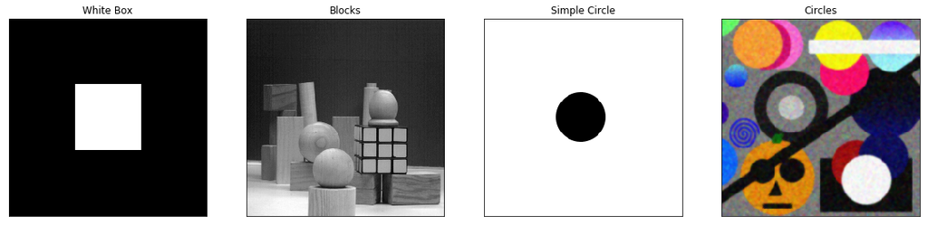

```python
def color2gray(image):
    return 0.299 * image[:,:,0] + 0.587 * image[:,:,1] + 0.114 * image[:,:,2]

white_box = mpimg.imread("hough_images/2D_White_Box.png") # matplotlib
blocks = mpimg.imread("hough_images/blocks.png")
simplecircle = color2gray(mpimg.imread("hough_images/simplecircle.png"))
circles = color2gray(cv2.imread("hough_images/circles.png")[:,:,::-1]) # for comparison
color_circles = cv2.imread("hough_images/circles.png")[:,:,::-1]
images = [white_box, blocks, simplecircle, circles]
grayscale = [True, True, False, False]

k = 5
scale = 1
circles = cv2.GaussianBlur(circles, ksize=(k,k), sigmaX=scale, sigmaY=scale)
circles = cv2.medianBlur(circles.astype(np.uint8), 3)

color_circles = cv2.GaussianBlur(color_circles, ksize=(k,k), sigmaX=scale, sigmaY=scale)
color_circles = cv2.medianBlur(color_circles, 3)

def plot_image(im, ax=None, title=None, gray=True, cmap=None, colorbar=False):
    if not ax:
        ax = plt.subplots()[1]
    cmap = 'gray' if gray and cmap is None else cmap
    axim = ax.imshow(im, cmap=cmap)
    ax.set_xticks([])
    ax.set_yticks([])
    if title:
        ax.set_title(title)
    if colorbar:
        plt.colorbar(axim, ax=ax, fraction=0.046, pad=0.04)
    return axim

fig, axs = plt.subplots(1, 4, figsize=(20,8))
plot_image(white_box, axs[0], "White Box")
plot_image(blocks, axs[1], "Blocks")
plot_image(simplecircle, axs[2], "Simple Circle")
plot_image(color_circles, axs[3], "Circles", gray=False)

plt.show()
```

# Gradient Magnitude, Direction

Here we calculate the gradient magnitude using a finite difference method, aka the Sobel filter.  
The gradient is defined as $\lim_{h\to0} \frac{f(x+h) - f(x)}{h}$ and can be approximated by $\frac{1}{2} [f(x+1) - f(x-1)]$.  
We compute the partial derivatives $L_x$ and $L_y$, then combine them to get the gradient magnitude and angle.

After experimenting with several thresholds below, we choose $0.5$ as our gradient threshold value for the blocks image.

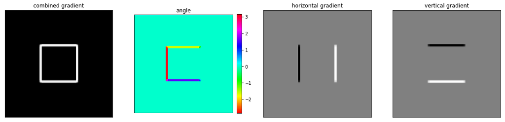

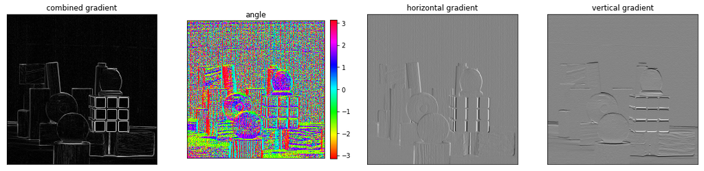

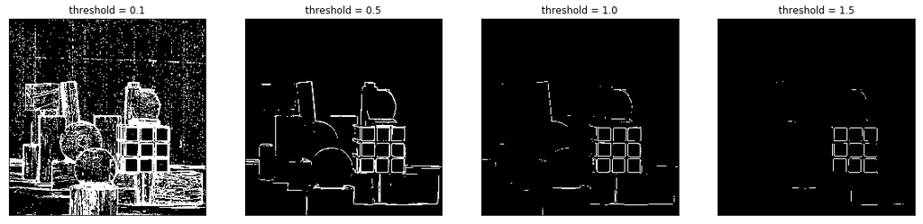

```python
def gradient(image):
    """Uses a Sobel filter to calculate gradient magnitude."""
    kx = np.array([
        [-1, 0, 1],
        [-2, 0, 2],
        [-1, 0, 1]
    ])
    ky = np.array([
        [-1, -2, -1],
        [0, 0, 0],
        [1, 2, 1]
    ])
    Lx = signal.convolve2d(image, kx, mode='valid')
    Ly = signal.convolve2d(image, ky, mode='valid')

    magnitude = np.sqrt(Lx**2 + Ly**2)
    angle = np.arctan2(Ly, Lx) # arctan modifies the second argument in-place

    return magnitude, angle, Lx, Ly

def threshold(magnitude, thresh):
    """Returns a binary black-white image where white represents the pixels
    greater than a given threshold."""
    return (magnitude > thresh).astype('uint8') * 255

# Plot gradient attributes for simple white box
fig, axs = plt.subplots(1, 4, figsize=(20,8))
mag, angle, Lx, Ly = gradient(white_box)
plot_image(mag, axs[0], title="combined gradient")
plot_image(angle, axs[1], title="angle", cmap='hsv', colorbar=True)
plot_image(Lx, axs[2], title="horizontal gradient")
plot_image(Ly, axs[3], title="vertical gradient")
plt.show()

# Plot gradient attributes for complicated blocks
fig, axs = plt.subplots(1, 4, figsize=(20,8))
mag, angle, Lx, Ly = gradient(blocks)
plot_image(mag, axs[0], title="combined gradient")
plot_image(angle, axs[1], title="angle", cmap='hsv', colorbar=True)
plot_image(Lx, axs[2], title="horizontal gradient")
plot_image(Ly, axs[3], title="vertical gradient")
plt.show()

# Plot potential thresholds for complicated blocks
fig, axs = plt.subplots(1, 4, figsize=(20,8))
mag, angle, Lx, Ly = gradient(blocks)
for i, thresh in enumerate([0.1, 0.5, 1.0, 1.5]):
    plot_image(threshold(mag, thresh), axs[i], title="threshold = {}".format(thresh))
plt.show()
```

# Laplacian Kernel and Zero Crossings

The Laplacian kernel $$ \left[ \begin{matrix} 0 & 1 & 0 \\ 1 & -4 & 1 \\ 0 & 1 & 0 \\ \end{matrix} \right] $$ is a second-derivative approximation. An alternative Laplacian kernel is also listed below. We look for points when the second derivative changes sign; this is a zero-crossing. Checking the Laplacian for zero-crossings catches more gradual changes than gradient magnitude does. It is also susceptible to noise, so we threshold the zero-crossings; the change must be at least a certain value. The zero-crossing is computed by taking each point in the Laplacian and checking if a 3x3 neighborhood contains both positive and negative values.

We then use the Laplacian zero-crossings and gradient magnitudes to mask each other, taking edges to be points which appear in both.

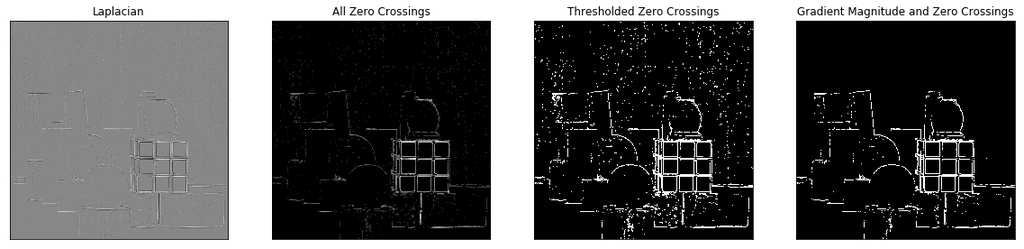

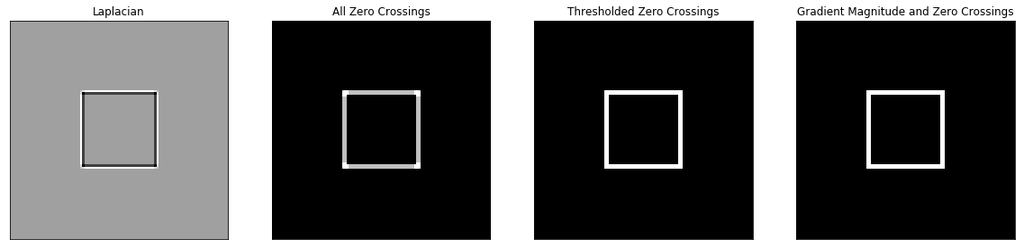

```python
def laplacian(image, k=5, scale=1, thresh=0.01):
    """LoG filter with thresholding. Threshold the absolute value."""
#     image = cv2.GaussianBlur(image, ksize=(k,k), sigmaX=scale, sigmaY=scale)
    kernel = np.array([
        [0, 1, 0],
        [1, -4, 1],
        [0, 1, 0]
    ])
    kernel = np.array([
        [1, 1, 1],
        [1, -8, 1],
        [1, 1, 1]
    ])

    lap = signal.convolve2d(image, kernel, mode='valid')
    lap[np.bitwise_and(-thresh < lap, lap < thresh)] = 0
    return lap

def zero_crossings(image, thresh=0.01):
    lap = laplacian(image, thresh=thresh)

    m, n = lap.shape
    all_crossings = np.zeros_like(lap)

    clip = lambda x, x_max: np.clip(x, 0, x_max)

    for i in range(m):
        for j in range(n):
            nhood = lap[clip(i-1,m):clip(i+2,m),clip(j-1,n):clip(j+2,n)]
            if nhood.max() > 0 and nhood.min() < 0:
                all_crossings[i,j] = nhood.max() - nhood.min()

    thresh_crossings = np.where(all_crossings > thresh, 1, 0)

    return lap, thresh_crossings, all_crossings

def edges(image, mag_thresh=0.5, lap_thresh=0, return_cross=False):
    mag, angle, Lx, Ly = gradient(image)
    thresh = threshold(mag, thresh=mag_thresh)
    lap, cross, all_cross = zero_crossings(image, thresh=lap_thresh)
    thresh_edges = thresh * cross
    if return_cross:
        return thresh_edges, cross
    else:
        return thresh_edges

def canny_edges(image):
    return cv2.Canny(np.uint8(image), 100, 200)



thresh = 0.20
lap, cross, all_cross = zero_crossings(blocks, thresh)
mag = threshold(gradient(blocks)[0], thresh)

fig, axs = plt.subplots(1, 4, figsize=(20,8))
plot_image(lap, axs[0], title="Laplacian")
plot_image(all_cross, axs[1], title="All Zero Crossings")
plot_image(cross, axs[2], title="Thresholded Zero Crossings")
plot_image(mag * cross, axs[3], title="Gradient Magnitude and Zero Crossings")

thresh = 0.02
lap, cross, all_cross = zero_crossings(white_box, thresh)
mag = threshold(gradient(white_box)[0], thresh)

fig, axs = plt.subplots(1, 4, figsize=(20,8))
plot_image(lap, axs[0], title="Laplacian")
plot_image(all_cross, axs[1], title="All Zero Crossings")
plot_image(cross, axs[2], title="Thresholded Zero Crossings")
plot_image(mag * cross, axs[3], title="Gradient Magnitude and Zero Crossings")
```

# Circle Detection via Hough Transform

We also apply channel-wise edge detection. Notice, for example, that the orange pumpkin disappears when the color image is converted to grayscale. Taking only the red channel preserves the pumpkin. We detect edges in the red, green, and blue channel, then union those edges together.

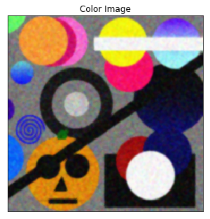

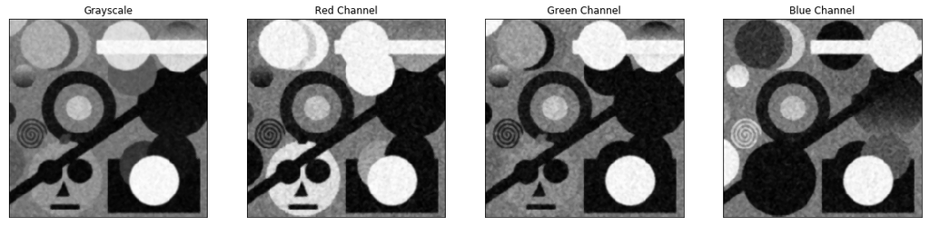

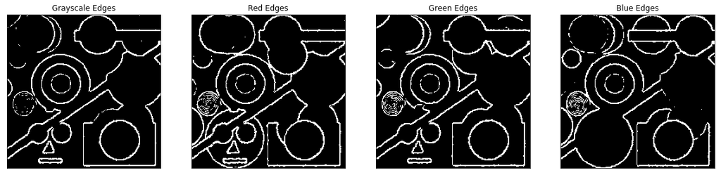

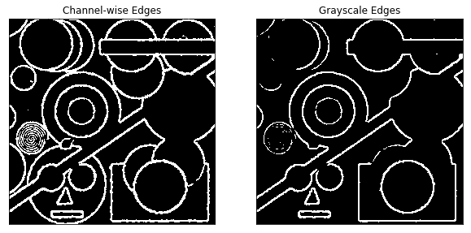

```python
mag_thresh = 150
lap_thresh = 1.50
grayscale_edges = edges(circles, mag_thresh=mag_thresh, lap_thresh=lap_thresh)
channel_edges = [edges(color_circles[:,:,i], mag_thresh=mag_thresh, lap_thresh=lap_thresh) for i in [0, 1, 2]]
# channel_edges = [canny_edges(color_circles[:,:,i]) for i in [0, 1, 2]]
color_edges = np.sum(channel_edges, axis=0)
color_edges = np.where(color_edges > 0, 1, 0)

fig, ax = plt.subplots(1, 1, figsize=(5,8))
plot_image(color_circles, ax, gray=False, title="Color Image")

fig, axs = plt.subplots(1, 4, figsize=(20,8))
plot_image(circles, axs[0], title="Grayscale")
plot_image(color_circles[:,:,0], axs[1], title="Red Channel")
plot_image(color_circles[:,:,1], axs[2], title="Green Channel")
plot_image(color_circles[:,:,2], axs[3], title="Blue Channel")

fig, axs = plt.subplots(1, 4, figsize=(20,8))
plot_image(grayscale_edges, axs[0], title="Grayscale Edges")
plot_image(channel_edges[0], axs[1], title="Red Edges")
plot_image(channel_edges[1], axs[2], title="Green Edges")
plot_image(channel_edges[2], axs[3], title="Blue Edges")

fig, axs = plt.subplots(1, 2, figsize=(10,8))
plot_image(color_edges, axs[0], title="Channel-wise Edges")
plot_image(grayscale_edges, axs[1], title="Grayscale Edges")
plt.show()
```

Here we compare our channel-wise edge detection with Canny edge detection. Notice that the orange pumpkin is quite visible.

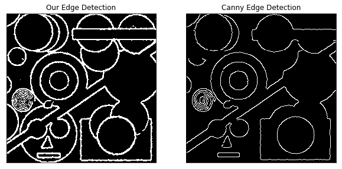

```python
canny = canny_edges(circles)
fig, axs = plt.subplots(1, 2, figsize=(10,8))
plot_image(color_edges, axs[0], title="Our Edge Detection")
plot_image(canny, axs[1], title="Canny Edge Detection")
plt.show()
```

```python
def hough_circle_accumulator(edges, r):
    """Finds circles in the image space, corresponding to local maxima in the accumulator space."""
    m, n = edges.shape
    ml, nl = m + 2 * r, n + 2 * r # expand the image dimensions
    edges_expanded = np.zeros((ml,nl))
    edges_expanded[r:-r,r:-r] = edges

    # Construct a larger array containing the image and an additional border
    # Circle centers can lie outside the image.
    acc = np.zeros((ml, nl))# contains potential circle centers

    # Template matching for circles of various sizes
    template = np.zeros((2 * r + 1, 2 * r + 1))

    for theta in np.linspace(0, 2 * np.pi, 20 * r):
        x = r + int(r * np.cos(theta))
        y = r + int(r * np.sin(theta))
        template[x,y] = 1

    conv = signal.convolve2d(edges_expanded, template, mode='same')

#     # Handle edge cases where the circle center is outside the image.
#     # We want to scale by 2π/θ, where θ is the angle length that lies inside the image.
#     # We approximate θ by 2 * arccos(d/r), where d is the distance to the image edge and r is the radius.
#     for i in range(r // 2, 2 * r):
#         d = r - i
#         factor = np.pi / np.arccos(np.clip(d / r, -1, 0.5)) # circle center must be at least 1/2 radius away

#         # upper rows
#         conv[i,:] *= factor
#         # lower rows
#         conv[-i,:] *= factor
#         # left columns
#         conv[:,i] *= factor
#         # right columns
#         conv[:,-i] *= factor

    return conv

def clip(idx):
    return int(max(idx,0))

rs = [16, 32, 48]
acc = [hough_circle_accumulator(color_edges, r) for r in rs]
```

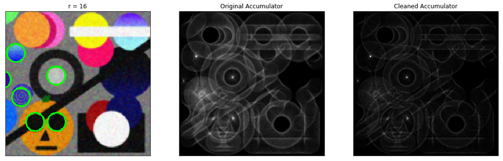

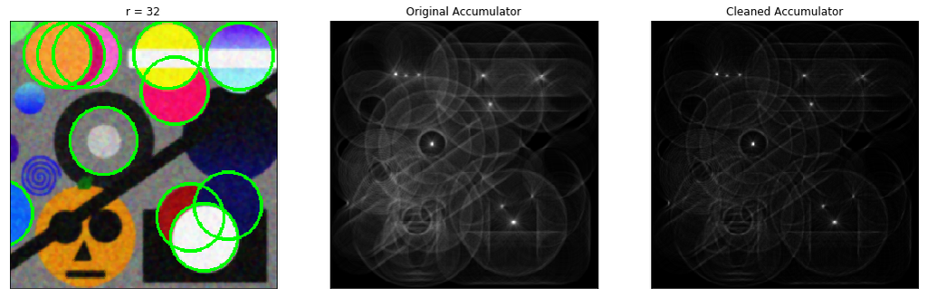

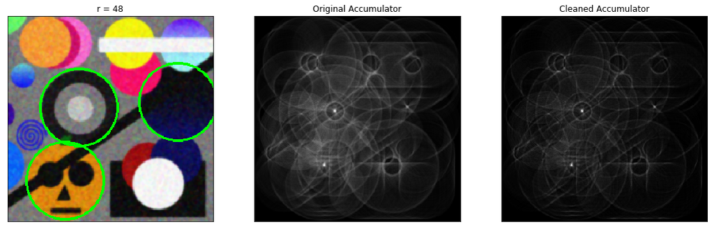

```python
def filter_accumulator(a):
    m, n = a.shape

    a_new = a.copy()
    for i in range(3, m-3):
        for j in range(3, n-3):
            a_new[i,j] = a[i,j] ** 2 / np.median(a[i-3:i+4,j-3:j+4]+1)

    return a_new

def hough_peaks(im, a_thresh, nhood_size, r):
    peaks = []
    im_temp = im.copy()

    i_peak = 0
    false_positives = 0
    while false_positives < 5 and len(peaks) < 15:
        max_loc = np.unravel_index(np.argmax(im_temp), im_temp.shape)
        i, j = max_loc
        max_val = im[max_loc]
        is_peak = max_val >= a_thresh
#         print("({},{}), max: {} {}".format(i, j, max_val, "false positive" if not is_peak else ""))
        if is_peak:
            peaks.append((i - r, j - r))
            i_peak += 1
        else:
            false_positives += 1
        t = nhood_size//2.0
        im_temp[clip(i-t):int(i+t+1), clip(j-t):int(j+t+1)] = 0


    return np.array(peaks)


def plot_peaks(im, r, peaks):
    im = im.copy()
    for peak in peaks:
        s = int(np.max(im))
        cv2.circle(img=im, center=(int(peak[1]), int(peak[0])), radius=r, color=(0,s,0), thickness=2)
    return im


a_thresholds = [120, 200, 250]
for a, r, a_t in zip(acc, rs, a_thresholds):
    a_clean = filter_accumulator(a)
    peaks = hough_peaks(a_clean, a_thresh=a_t, nhood_size=24, r=r)
    a_marked = plot_peaks(color_circles, r=r, peaks=peaks)
    fig, axs = plt.subplots(1, 3, figsize=(18,8))
    axs[0].imshow(a_marked)
    axs[0].set_title("r = {}".format(r))

    axs[1].imshow(a, cmap='gray', vmax=a.max())
    axs[1].set_title("Original Accumulator")

    axs[2].imshow(a_clean, cmap='gray', vmax=a_clean.max())
    axs[2].set_title("Cleaned Accumulator")

    for ax in axs:
        ax.set_xticks([])
        ax.set_yticks([])

    plt.show()
```

# Results

We detected 19/20 circles, with only one false positive. Well done!  
Helpful techniques were

- Gaussian blur and median filtering on the original image
- Channel-wise edge detection
- Local median filter in the accumulator
- Template matching with a circular kernel to speed up the Hough transform

Potential further work is

- Using gradient orientation information in template matching
- Proper scaling for circles with centers outside the original image